# Data Nuggets

Author

OWID

Published

05 May 2025

## Antibiotics Use

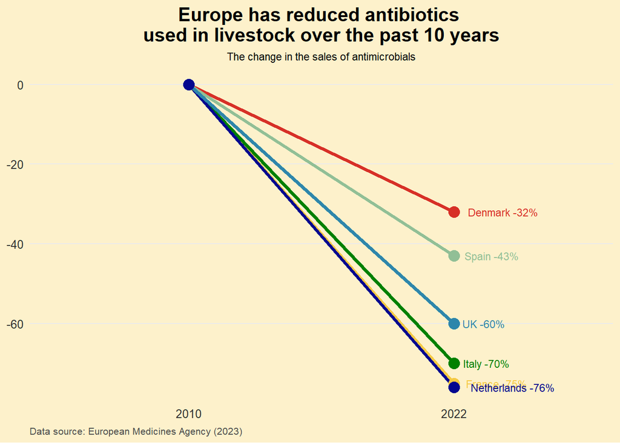

```r
library(tidyverse)
library(dplyr)
library(ggrepel)

# Data (as provided in the image)
data_anti <- data.frame(
  Country = c("Denmark", "Spain", "UK", "Italy", "France", "Netherlands"),
  Year_2010 = c(0, 0, 0, 0, 0, 0),
  Year_2022 = c(-32, -43, -60, -70, -75, -76)
)

# Reshape the data for ggplot2
data_long <- data_anti %>%
  tidyr::pivot_longer(
    cols = starts_with("Year"),
    names_to = "Year",
    values_to = "Change"
  ) %>%
  mutate(Year = gsub("Year_", "", Year))  # Remove "Year_"

# Define colors for each country
country_colors <- c("Denmark" = "#d73027", "Spain" = "#91bf96", "UK" = "#2e86ab", "Italy" = "#018000", "France" = "#F5CA45","Netherlands" = "#04078f")

# Create the line chart
ggplot(data_long, aes(x = Year, y = Change, group = Country, color = Country)) +
  geom_line(linewidth = 1.3) +
  geom_point(size = 4.1) +
  scale_color_manual(values = country_colors) +
  geom_text(
    data = data_long %>% filter(Year == "2022"),
    aes(label = paste0(Country, " ", Change, "%")),
    hjust = -0.2,
    vjust = 0.5,
    size = 3
  ) +
  labs(
    title = "Europe has reduced antibiotics \nused in livestock over the past 10 years",
    subtitle = "The change in the sales of antimicrobials",
    caption = "Data source: European Medicines Agency (2023)" ) +
  theme_minimal() + # Use a minimal theme
  theme(
    axis.title.x = element_blank(), # Remove x-axis title
    axis.title.y = element_blank(), # Remove y-axis title
    legend.text = element_text(size = rel(0.8)),
    legend.key.size = unit(0.6, "lines"),
    legend.justification = "center",
    legend.position = "none",
    axis.text = element_text(color = "grey20", size = rel(0.9)),
    plot.title = element_text(size = rel(1.4), color = "black", face = "bold", hjust = 0.5),
        plot.subtitle = element_text(size = rel(0.8), color = "black", hjust = 0.5),
    plot.caption = element_text(size = rel(0.7), color = "grey30", hjust = 0),
    panel.background = element_rect(fill = "#FDF1CB",
                                colour = "#FDF1CB",
                                size = 0, linetype = "solid"),
    panel.border = element_blank(),
    plot.background = element_rect(fill = "#FDF1CB", color = NA),
    panel.grid.major.x = element_blank(), # Remove vertical grid lines
    panel.grid.minor = element_blank()    # Remove minor grid lines
  )
```

**Source: Our World in Data (chart reproduced)**

Antibiotics can play an important role in preventing disease and improving the health of animals. But overusing them, particularly for livestock, poses a risk to human health through [antibiotic resistance](https://ourworldindata.org/antibiotics).

Over the last decade, Europe has made much progress in reducing antibiotic use in farm animals. This has been achieved through stricter regulations and, in some countries, taxes on antibiotics.

Antibiotic use has fallen by over half in some countries, such as the UK, Italy, France, and the Netherlands.

These countries have still managed to maintain productive agricultural sectors by focusing on other ways to manage disease risk and animal growth, such as vaccinations, ventilation, cleaner equipment, and high-quality diets.

Go to the original link at [OWID](https://ourworldindata.org/data-insights/2)